# Course Project

Omar Juarez

3 de febrero de 2020

## Abstract

In this document we are going to analyse the data provided by Human Activity Recognition. Our goal is to determine if the exercises of the participants in this test were done properly. In this particular case what we want to predict the “classe” variable based on the regressors. This variable can take 5 labels(from A to E) so we will compare the results of two methods that we have learned in this course: Decision Trees and Random Forest and the we will select the best model according the accuracy of each one.

## Data Loading

```r
library(dplyr)
```

```r
library(lattice)
library(ggplot2)
library(caret)
library(kernlab)
library(rpart)
library(rpart.plot)
library(corrplot)
library(randomForest)
library(e1071)
library(rattle)
set.seed(12345)

setwd("D:/02 Coursera/02 R/01 Johns Hopkings-Coursera/08 Machine Learning/Data")

trainUrl = "http://d396qusza40orc.cloudfront.net/predmachlearn/pml-training.csv"

testUrl = "http://d396qusza40orc.cloudfront.net/predmachlearn/pml-testing.csv"

TrainFile = "./data/pml-training.csv"

TestFile = "./data/pml-testing.csv"

if(!file.exists("./data")){
  dir.create(path = "./data")
}

if(!file.exists(TrainFile)){
  download.file(trainUrl,destfile = TrainFile, method = "curl")
}

if(!file.exists(TestFile)){
  download.file(testUrl,destfile = TestFile,method = "curl")
}

Flag_Training = read.csv(TrainFile)
Flag_Test = read.csv(TestFile)
```

## Cleaning data

1. We can remove variables that do not change between observations. In this case, since the variables are not binary, we can remove them without biased our model.
2. We can also remove the variables that contain missing values (i.e NA’s)

We can create a Correlation Matrix to have hint about which variables might influence others.

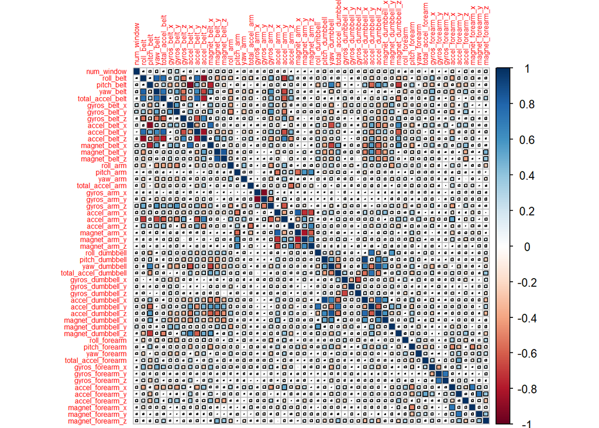

## Creating Data Partition

Once we have done the cleaning and an overlook about the correlations, we now can split the data into the training set and the testing (or validation) set. Just like the course we are going to split the data into 70% for the training and 30% for the validation dataset. This partition has to be done with the trainig dataset not with test daset otherwise our prediction would be biased.

## Decision Tree: Analysis

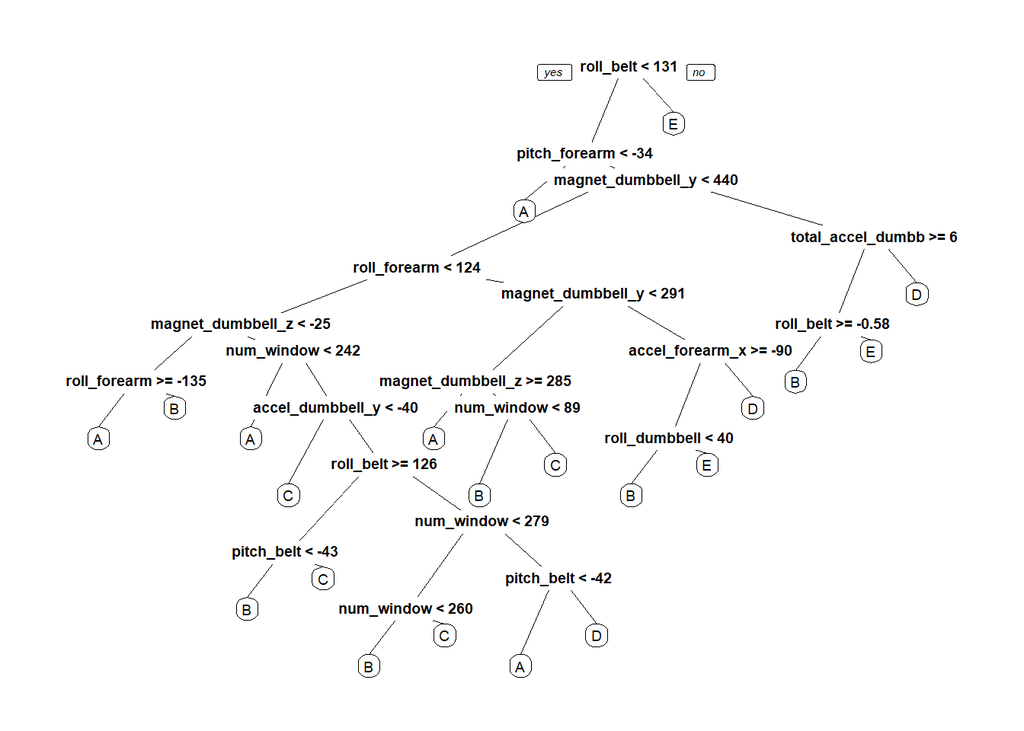

```
## Confusion Matrix and Statistics
##
##           Reference
## Prediction    A    B    C    D    E
##          A 1502   58    4   90   20
##          B  201  660   66  148   64
##          C   59   37  815   54   61
##          D   66   64  129  648   57
##          E   74  114   72  126  696
##
## Overall Statistics
##
##                Accuracy : 0.7342
##                  95% CI : (0.7228, 0.7455)
##     No Information Rate : 0.3232
##     P-Value [Acc > NIR] : < 2.2e-16
##
##                   Kappa : 0.6625
##
##  Mcnemar's Test P-Value : < 2.2e-16
##
## Statistics by Class:
##
##                      Class: A Class: B Class: C Class: D Class: E
## Sensitivity            0.7897   0.7074   0.7505   0.6079   0.7751
## Specificity            0.9568   0.9033   0.9560   0.9344   0.9226
## Pos Pred Value         0.8973   0.5795   0.7943   0.6722   0.6433
## Neg Pred Value         0.9050   0.9425   0.9442   0.9151   0.9579
## Prevalence             0.3232   0.1585   0.1845   0.1811   0.1526
## Detection Rate         0.2552   0.1121   0.1385   0.1101   0.1183
## Detection Prevalence   0.2845   0.1935   0.1743   0.1638   0.1839
## Balanced Accuracy      0.8733   0.8053   0.8532   0.7712   0.8488
```

## Ramdom Forest

```
## Random Forest
##
## 13737 samples
##    54 predictor
##     5 classes: 'A', 'B', 'C', 'D', 'E'
##
## No pre-processing
## Resampling: Cross-Validated (5 fold)
## Summary of sample sizes: 10988, 10990, 10990, 10990, 10990
## Resampling results across tuning parameters:
##
##   mtry  Accuracy   Kappa
##    2    0.9925746  0.9906063
##   30    0.9970880  0.9963167
##   58    0.9934484  0.9917126
##
## Accuracy was used to select the optimal model using the largest value.
## The final value used for the model was mtry = 30.
```

```
## Confusion Matrix and Statistics
##
##           Reference
## Prediction    A    B    C    D    E
##          A 1674    0    0    0    0
##          B    1 1138    0    0    0
##          C    0    1 1025    0    0
##          D    0    0    2  962    0
##          E    0    0    0    1 1081
##
## Overall Statistics
##
##                Accuracy : 0.9992
##                  95% CI : (0.998, 0.9997)
##     No Information Rate : 0.2846
##     P-Value [Acc > NIR] : < 2.2e-16
##
##                   Kappa : 0.9989
##
##  Mcnemar's Test P-Value : NA
##
## Statistics by Class:
##
##                      Class: A Class: B Class: C Class: D Class: E
## Sensitivity            0.9994   0.9991   0.9981   0.9990   1.0000
## Specificity            1.0000   0.9998   0.9998   0.9996   0.9998
## Pos Pred Value         1.0000   0.9991   0.9990   0.9979   0.9991
## Neg Pred Value         0.9998   0.9998   0.9996   0.9998   1.0000
## Prevalence             0.2846   0.1935   0.1745   0.1636   0.1837
## Detection Rate         0.2845   0.1934   0.1742   0.1635   0.1837
## Detection Prevalence   0.2845   0.1935   0.1743   0.1638   0.1839
## Balanced Accuracy      0.9997   0.9995   0.9989   0.9993   0.9999
```

```
## [1] 0.0008496177
```

## Conclusions

If we use random forest the accuracy increases a lot, so based on the results this is the model we can use. However we could do so more analysis via Area Under the Receiver Operating Characteristics(AUROC), this will tell us the how the model is capable of distinguish between classes, but this is a more advanced topic in the data science field. Another thing to consider is to make a logistic regression and compare it’s result with the previous model.